# Machine Learning

# 3. Backpropagation

# Let's be clear on what we need to compute

$\forall l \in [1\ldots,L]$:

1. $\nabla_{\mbf{W}^l}\mathcal{L}(\mbf{x},y;\{\mbf{W},b\})$
2. $\nabla_{\mbf{b}^l}\mathcal{L}(\mbf{x},y;\{\mbf{W},b\})$

[figure not shown]

# Once you have gradients on ALL weights $\implies$ We can update

$\forall l \in [1\ldots,L]$:

1. $\mbf{W}^l \leftarrow \mbf{W}^l - \gamma \nabla_{\mbf{W}^l}\mathcal{L}(\mbf{x},y;\{\mbf{W},b\})$
2. $\mbf{b}^l \leftarrow \mbf{b}^l - \gamma \nabla_{\mbf{b}^l}\mathcal{L}(\mbf{x},y;\{\mbf{W},b\})$

# How do we get all the weights?

[Mostly taken from here](https://www.youtube.com/watch?v=i94OvYb6noo)

# Chain Rule

Returning to functions of a single variable, suppose that $y = f(g(x))$ and that the underlying functions $y=f(u)$ and $u=g(x)$ are both differentiable. The chain rule states that

$$\frac{dy}{dx} = \frac{dy}{du} \frac{du}{dx}.$$

What is the **derivative of loss wrt x in the equation below**? $$y = loss\big(g(h(i(x)))\big)$$

$$\frac{\partial loss}{\partial x} = \frac{\partial loss}{\partial g} \frac{\partial g}{\partial h}\frac{\partial h}{\partial i}\frac{\partial i}{\partial x}$$

# Chain Rule on Directed Acyclic Graph (DAG)

### Automate the computation of derivatives with computer science

1. Forward Pass
2. Backward Pass

# Forward Pass

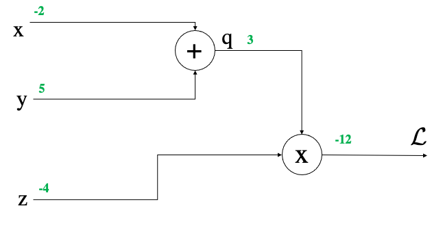

**This is what we wanted:** $$\frac{\partial\mathcal{L}}{\partial x},\frac{\partial\mathcal{L}}{\partial y},\frac{\partial\mathcal{L}}{\partial z}$$

**Forward pass**

1. Evaluate the function on input *(the function is "hard-coded" with your model/code)*
2. Store **"local" derivative** at each layer/gate

$$\frac{\partial\mathcal{L}}{\partial q}=z, \frac{\partial\mathcal{L}}{\partial z}=q, \frac{\partial\mathcal{q}}{\partial x}=1, \frac{\partial\mathcal{q}}{\partial y}=1$$

# Backward Pass

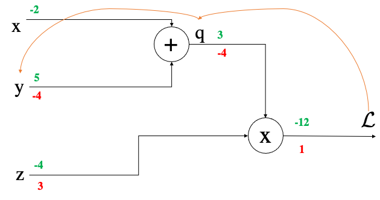

**What is the value of the gradient of $\mathcal{L}$ on $y$?**: $$\frac{\partial\mathcal{L}}{\partial y} = \frac{\partial\mathcal{L}}{\partial q}\frac{\partial q}{\partial y} = z\cdot 1= -4$$

**This is what we wanted:** $$\frac{\partial\mathcal{L}}{\partial x},\frac{\partial\mathcal{L}}{\partial y},\frac{\partial\mathcal{L}}{\partial z}$$

**Backward pass**

1. Start from loss scalar value
2. Backpropagate the current derivative/gradient to higher layers
3. Use chain rule to aggregate a) local derivative b) what arrives from "the top"

$$\frac{\partial\mathcal{L}}{\partial q}=z, \frac{\partial\mathcal{L}}{\partial z}=q, \frac{\partial\mathcal{q}}{\partial x}=1, \frac{\partial\mathcal{q}}{\partial y}=1$$

# Backward Pass

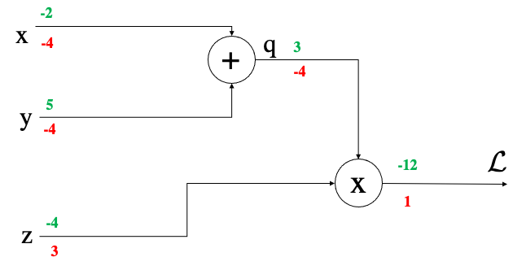

**This is what we wanted:** $$\frac{\partial\mathcal{L}}{\partial x},\frac{\partial\mathcal{L}}{\partial y},\frac{\partial\mathcal{L}}{\partial z}$$

**This is what we have**

$$\frac{\partial\mathcal{L}}{\partial q}=z, \frac{\partial\mathcal{L}}{\partial z}=q, \frac{\partial\mathcal{q}}{\partial x}=1, \frac{\partial\mathcal{q}}{\partial y}=1$$

# Check with our manual derivation ✅

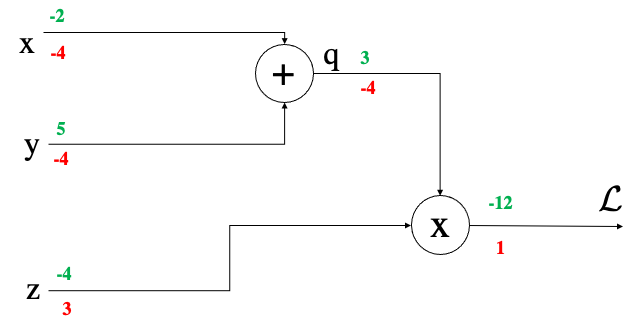

The high school way (as we did until now):

$$\frac{\partial\mathcal{L}(x,y,z)}{\partial x} = (\mbf{x}z+yz)^{\prime}=(\mbf{x}z)^{\prime}+(yz)^{\prime} = z = -4$$$$\frac{\partial\mathcal{L}(x,y,z)}{\partial y} = (xz+\mbf{y}z)^{\prime}=(xz)^{\prime}+(\mbf{y}z)^{\prime} = z = -4$$$$\frac{\partial\mathcal{L}(x,y,z)}{\partial z} = x+y = +3 $$

# You know what? I do not trust math, I want to verify with a machine ✅

# Pytorch check

```
from torch import tensor

def neural_net(x,y,z):
    return (x+y)*z

x, y, z = tensor(-2., requires_grad=True), tensor(5.,requires_grad=True), tensor(-4., requires_grad=True)
loss = neural_net(x,y,z) # forward pass
loss.backward()          # backward (after this I can check the gradients)
for el in [x,y,z]:
    print(el.grad)
```

```
tensor(-4.)
tensor(-4.)
tensor(3.)
```

# Pytorch check

- Pytorch creates a **dynamic computational directed acyclic graph (DAG) under the hood.**
- We can also see the graph with Pytorch if you want (`torchviz` simplifies the plot)
- `! pip install torchviz`

```python
from torchviz import make_dot
from torch import tensor
def neural_net(x,y,z):
    return (x+y)*z

x, y, z = tensor(-2., requires_grad=True), tensor(5.,
                                                  requires_grad=True), tensor(-4., requires_grad=True)
loss = neural_net(x, y, z)  # forward pass

loss.backward()  # backward (ok now I can check the gradients)
for el in [x, y, z]:
    print(el.grad)
print(loss)
make_dot(loss, params=dict([('x', x),('y', y),('z', z)]))
```

```
tensor(-4.)
tensor(-4.)
tensor(3.)
tensor(-12., grad_fn=<MulBackward0>)
```

[figure not shown]

# We can also see the DAG of AlexNet... [paper from 2012]

# ...but it won't fit my screen

```python
import torch
from torchvision.models import AlexNet
model = AlexNet()
x = torch.randn(1, 3, 227, 227).requires_grad_(True)
y = model(x)
make_dot(y, params=dict(list(model.named_parameters()) + [('x', x)]))
```

[output not shown]

# General Recipe for Chain Rule over DAGs [Forward]

**Just remember that you have to do at a generic gate:**

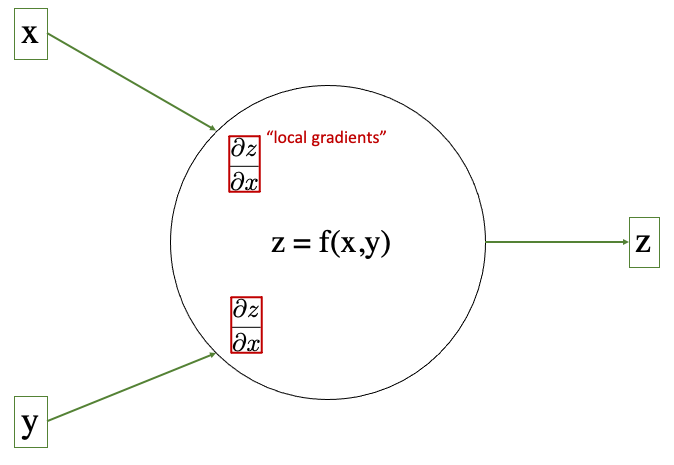

# General Recipe for Chain Rule over DAGs [Backward]

**Multiply the gradient that you receive with your local gradient**

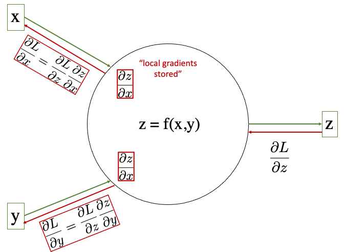

# Exam Question Lookalike

$$ f(w, x)=\frac{1}{1+e^{-\left(w_{0} x_{0}+w_{1} x_{1}+b\right)}} $$

Given the above function, can you perform **forward and backward pass** by writing all the local values and local gradient, by applying the chain rule?

*(Direct computation of the gradient does not count for solving it, though you may be using it to double check)*

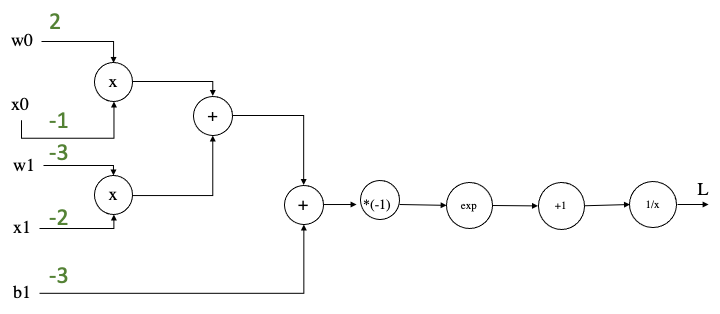

# Exam Question Lookalike [Forward Pass]

$$ f(w, x)=\frac{1}{1+e^{-\left(w_{0} x_{0}+w_{1} x_{1}+b\right)}} $$

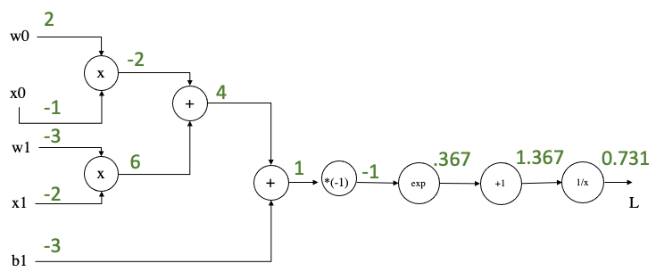

# Do not forget to store local gradients!

$$ f(w, x)=\frac{1}{1+e^{-\left(w_{0} x_{0}+w_{1} x_{1}+b\right)}} $$

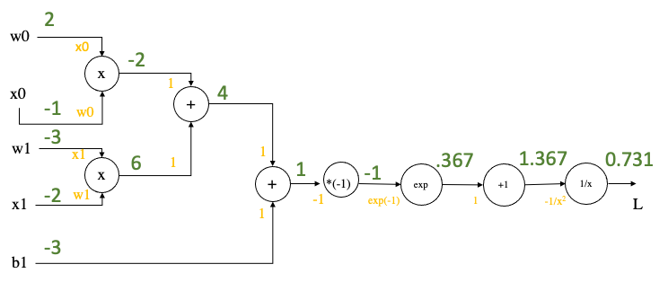

# Local gradients evaluated at input values! Now ready to go backwards

$$ f(w, x)=\frac{1}{1+e^{-\left(w_{0} x_{0}+w_{1} x_{1}+b\right)}} $$

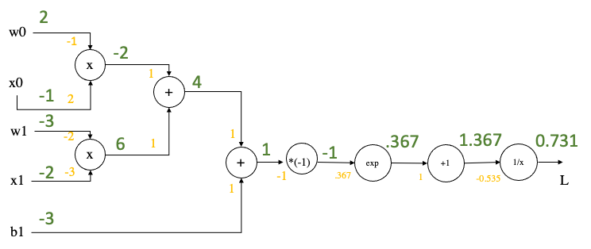

# End Forward; Now Ready to Backprop [Backward]

$$ f(w, x)=\frac{1}{1+e^{-\left(w_{0} x_{0}+w_{1} x_{1}+b\right)}} $$

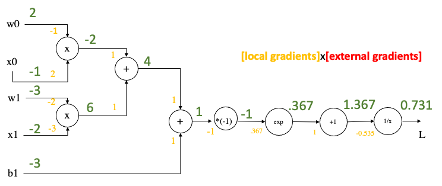

# End Forward; Now Ready to Backprop [Backward]

$$ f(w, x)=\frac{1}{1+e^{-\left(w_{0} x_{0}+w_{1} x_{1}+b\right)}} $$

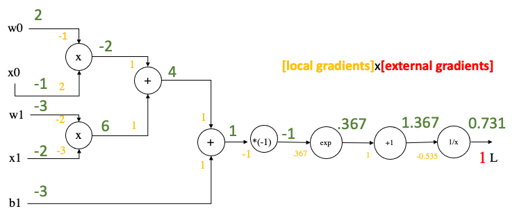

# End Forward; Now Ready to Backprop [Backward]

$$ f(w, x)=\frac{1}{1+e^{-\left(w_{0} x_{0}+w_{1} x_{1}+b\right)}} $$

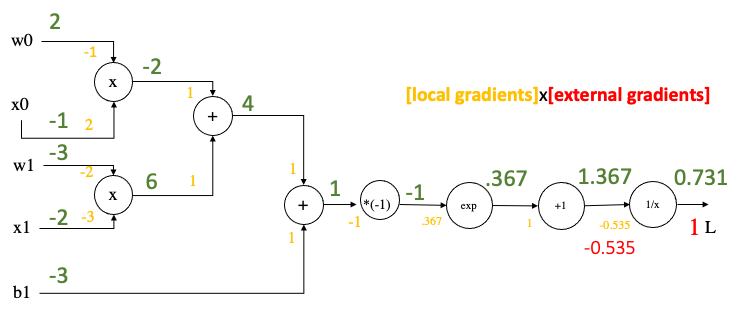

# End Forward; Now Ready to Backprop [Backward]

$$ f(w, x)=\frac{1}{1+e^{-\left(w_{0} x_{0}+w_{1} x_{1}+b\right)}} $$

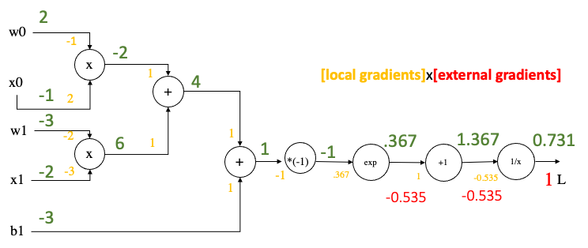

# End Forward; Now Ready to Backprop [Backward]

$$ f(w, x)=\frac{1}{1+e^{-\left(w_{0} x_{0}+w_{1} x_{1}+b\right)}} $$

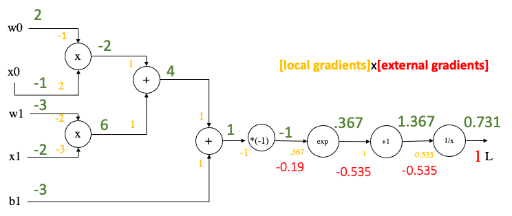

# End Forward; Now Ready to Backprop [Backward]

$$ f(w, x)=\frac{1}{1+e^{-\left(w_{0} x_{0}+w_{1} x_{1}+b\right)}} $$

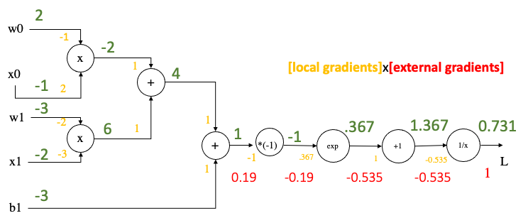

# End Forward; Now Ready to Backprop [Backward]

$$ f(w, x)=\frac{1}{1+e^{-\left(w_{0} x_{0}+w_{1} x_{1}+b\right)}} $$

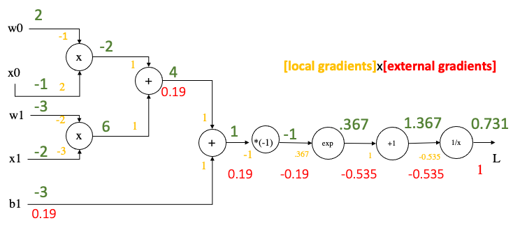

# End Backward

$$ f(w, x)=\frac{1}{1+e^{-\left(w_{0} x_{0}+w_{1} x_{1}+b\right)}} $$

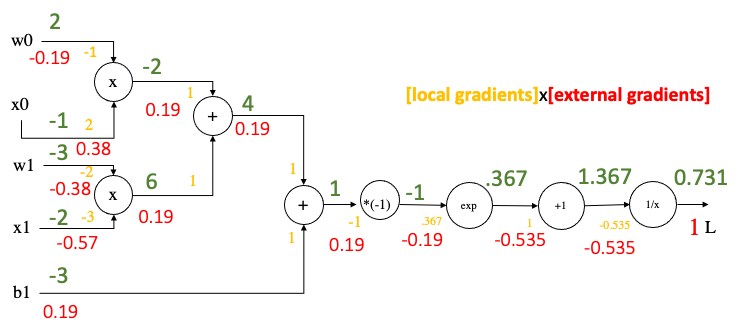

# Logistic Regression Computational Graph could be simplified

$$ f(w, x)=\frac{1}{1+e^{-\left(w_{0} x_{0}+w_{1} x_{1}+b\right)}} $$

This is what implements the **Sigmoid Layer in Pytorch:**

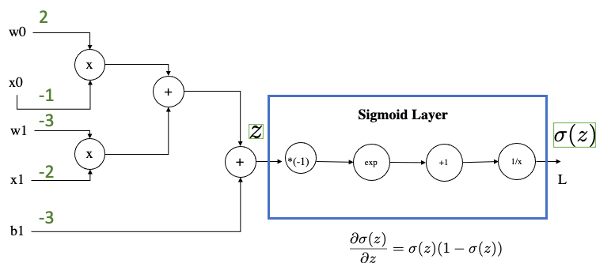

# Logistic Regression Computational Graph could be simplified

$$ f(w, x)=\frac{1}{1+e^{-\left(w_{0} x_{0}+w_{1} x_{1}+b\right)}} $$

This is what implements the **Sigmoid Layer in Pytorch:**

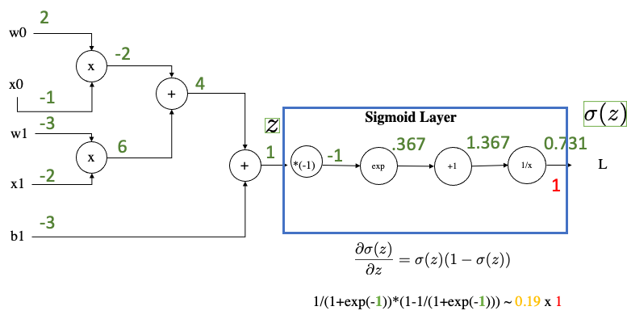

# Logistic Regression Computational Graph could be simplified

$$ f(w, x)=\frac{1}{1+e^{-\left(w_{0} x_{0}+w_{1} x_{1}+b\right)}} $$

This is what implements the **Sigmoid Layer in Pytorch:**

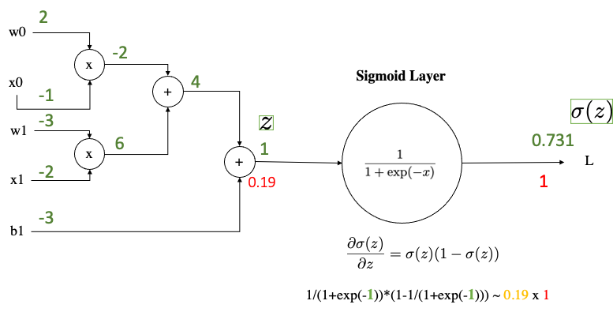

# What PyTorch does very roughly [Pseudo code]

```
class ComputationalGraph:

    def forward(inputs):
        #1. pass inputs to input layers/gate
        #2. forward the computational graph
        for gate in self.graph.nodes_topologically_sorted():
            gate.forward()
        return loss # the finale gate outputs the loss

    def backward():
        for gate in reversed(self.graph.nodes_topologically_sorted()):
            gate.backward() # chain rule applied with local grads
        return inputs_grads
```

# What is a Gate (ex. Multiplicative Scalar Gate) [Pseudo code]

```
class MultiplyGate:

    def forward(x,y):
        self.x = x # save local grads dz/dy
        self.y = y # save local grads dz/dx
        return x*y # eval function z = x + y

    def backward(dz):
        dx = self.y * dz # [dz/dx * dL/dz]
        dy = self.x * dz # [dz/dy * dL/dz]
        return [dx, dy]
```

# Are we done with training neural nets?

# Not completely: till now scalars, but we have matrices and vectors!

# Now this looks more familiar

$\forall l \in [1\ldots,L]$:

1. $\mbf{W}^l \leftarrow \mbf{W}^l - \gamma \nabla_{\mbf{W}^l}\mathcal{L}(\mbf{x},y;\{\mbf{W},b\})$
2. $\mbf{b}^l \leftarrow \mbf{b}^l - \gamma \nabla_{\mbf{b}^l}\mathcal{L}(\mbf{x},y;\{\mbf{W},b\})$

# Appendix: Gradient of Softmax wrt its probability

# Gradient of SoftMax + CE Loss wrt $z$

\begin{split}\begin{aligned} \mathcal{L}(\mathbf{y}, \hat{\mathbf{y}}) &= - \sum_{j=1}^q y_j \log \frac{\exp(z_j)}{\sum_{k=1}^q \exp(z_k)} \\ &= \sum_{j=1}^q y_j \underbrace{\log \sum_{k=1}^q \exp(z_k)}_{\text{not vary with j = constant}} - \sum_{j=1}^q y_j z_j\\ &= \log \sum_{k=1}^q \exp(z_k) \quad \underbrace{\sum_{j=1}^q y_j}_{=1} \quad - \sum_{j=1}^q y_j z_j\\ &= \log \sum_{k=1}^q \exp(z_k) - \sum_{j=1}^q y_j z_j. \end{aligned}\end{split}

[Taken from here](https://d2l.ai/chapter_linear-networks/softmax-regression.html?highlight=softmax#softmax-and-derivatives)

# Gradient of SoftMax + CE Loss wrt $z$

Below we take the **partial derivative wrt class j, so it is not in vector notation:**

$$\partial_{z_j} \mathcal{L}(\mathbf{y}, \hat{\mathbf{y}}) = \frac{\exp(z_j)}{\sum_{k=1}^q \exp(z_k)} - y_j = \mathrm{softmax}(\mathbf{z})_j - y_j$$

**It is a GLM!**

# Gradient of SoftMax + CE Loss wrt $z$

Below we take the **partial derivative wrt class j, so it is not in vector notation:**

$$\partial_{z_j} \mathcal{L}(\mathbf{y}, \hat{\mathbf{y}}) = \frac{\exp(z_j)}{\sum_{k=1}^q \exp(z_k)} - y_j = \mathrm{softmax}(\mathbf{z})_j - y_j$$

```
p = [0.2 0.7 0.1] y =[0 1 0]

dL/dz  = [0.2 (0.7-1) 0.1] = [0.2 -0.3 0.1]
```

# Now this looks more familiar

$\forall l \in [1\ldots,L]$:

1. $\mbf{W}^l \leftarrow \mbf{W}^l - \gamma \nabla_{\mbf{W}^l}\mathcal{L}(\mbf{x},y;\{\mbf{W},b\})$
2. $\mbf{b}^l \leftarrow \mbf{b}^l - \gamma \nabla_{\mbf{b}^l}\mathcal{L}(\mbf{x},y;\{\mbf{W},b\})$

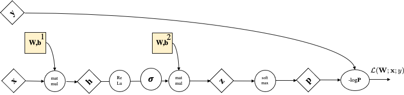

$$\chain{\mathcal{L}}{\mbf{W}^1} =~~?~~$$

$$\chain{\mathcal{L}}{\mbf{W}^1} = \chain{\loss}{\mbf{z}}\chain{\mbf{z}}{\mbf{W}^1}$$

# Backprop

$$\chain{\mathcal{L}}{\mbf{W}^1} = \chain{\loss}{\mbf{z}}\chain{\mbf{z}}{\mbf{W}^1}$$

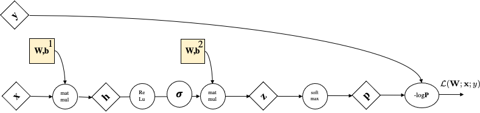

# Backprop

$$\chain{\mathcal{L}}{\mbf{W}^1} = \chain{\loss}{\mbf{z}}\chain{\mbf{z}}{\mbf{W}^1}$$

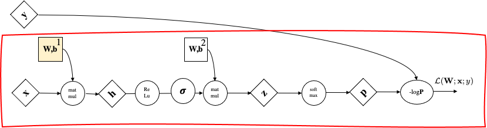

# Backprop

# Backprop

$$\chain{\mathcal{L}}{\mbf{W}^1} = \underbrace{\chain{\loss}{\mbf{z}}}_{\mathbb{R}^{1\times Z}}\underbrace{\chain{\mbf{z}}{\sigma}\chain{\mbf{\sigma}}{\mbf{W}^1}}_{\chain{\mbf{z}}{\mbf{W}^1}}$$

# Backprop

$$\chain{\mathcal{L}}{\mbf{W}^1} = \underbrace{\chain{\loss}{\mbf{z}}}_{\mathbb{R}^{1\times Z}}\underbrace{\chain{\mbf{z}}{\sigma}\chain{\mbf{\sigma}}{\mbf{W}^1}}_{\chain{\mbf{z}}{\mbf{W}^1}}$$$$ \chain{\mbf{z}}{\mbf{\sigma}} =~~?~~$$

# Backprop

$$\chain{\mathcal{L}}{\mbf{W}^1} = \underbrace{\chain{\loss}{\mbf{z}}}_{\mathbb{R}^{1\times Z}}\underbrace{\chain{\mbf{z}}{\sigma}\chain{\mbf{\sigma}}{\mbf{W}^1}}_{\chain{\mbf{z}}{\mbf{W}^1}}$$$$f : \mbf{\sigma} \mapsto \mbf{z} \quad \text{vector to vector}$$$$ \chain{\mbf{z}}{\mbf{\sigma}} =~~?~~; \mbf{z} = \mbf{W}\sigma+\mbf{b}$$

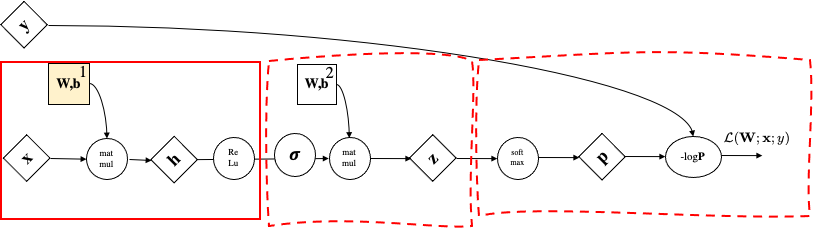

# Backprop

$$\chain{\mathcal{L}}{\mbf{W}^1} = \underbrace{\chain{\loss}{\mbf{z}}}_{1\times Z}\underbrace{\chain{\mbf{z}}{\sigma}}_{Z\times \Sigma}\chain{\mbf{\sigma}}{\mbf{W}^1}$$$$f : \mbf{\sigma} \mapsto \mbf{z} \quad \text{vector to vector}$$$$ \chain{\mbf{z}}{\mbf{\sigma}} = \mbf{W}^{[2]}; \quad \mbf{z} = \mbf{W}^{[2]}\sigma+\mbf{b}^{[2]}$$

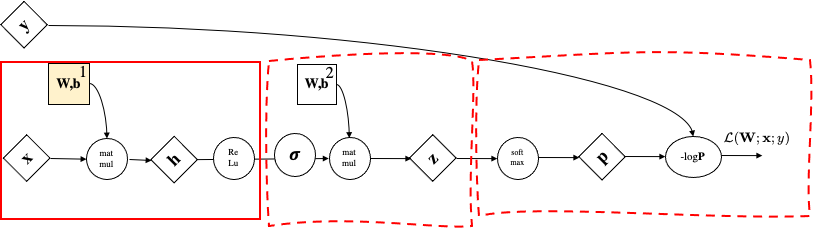

# Backprop

$$\chain{\mathcal{L}}{\mbf{W}^1} = \underbrace{\chain{\loss}{\mbf{z}}}_{1\times Z}\underbrace{\chain{\mbf{z}}{\sigma}}_{Z\times \Sigma}\chain{\mbf{\sigma}}{\mbf{W}^1}$$$$f : \mbf{\sigma} \mapsto \mbf{z} \quad \text{vector to vector}$$$$ \chain{\mbf{z}}{\mbf{\sigma}} = \mbf{W}^{[2]}; \quad \mbf{z} = \mbf{W}^{[2]}\sigma+\mbf{b}^{[2]}$$

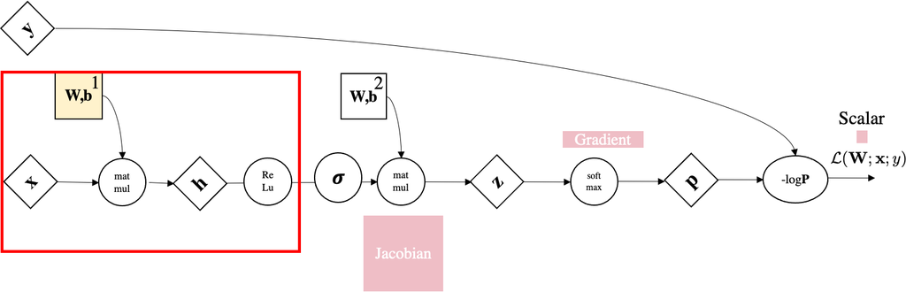

# Backprop

$$\chain{\mathcal{L}}{\mbf{W}^1} = \underbrace{\chain{\loss}{\mbf{z}}}_{1\times Z}\underbrace{\chain{\mbf{z}}{\sigma}}_{Z\times \Sigma}\chain{\mbf{\sigma}}{\mbf{W}^1}$$$$f : \mbf{\sigma} \mapsto \mbf{z} \quad \text{vector to vector}$$$$ \chain{\mbf{z}}{\mbf{\sigma}} = \mbf{W}^{[2]}; \quad \mbf{z} = \mbf{W}^{[2]}\sigma+\mbf{b}^{[2]}$$

# Backprop

$$\chain{\mathcal{L}}{\mbf{W}^1} = \underbrace{\chain{\loss}{\mbf{z}}}_{1\times Z}\underbrace{\chain{\mbf{z}}{\sigma}}_{Z\times \Sigma}\underbrace{\chain{\mbf{\sigma}}{\mbf{h}}\chain{\mbf{h}}{\mbf{W}^1}}_{\chain{\mbf{\sigma}}{\mbf{W}^1}}$$

# Backprop